# Human Activity Recognition Prediction

Sunday, February 22, 2015

*Executive Summary:*

Using devices such as Jawbone Up, Nike FuelBand, and Fitbit it is now possible to collect a large amount of data about personal activity relatively inexpensively. These type of devices are part of the quantified self movement. usually people quantify how much of a particular activity they do, but they rarely quantify how well they do it. In this project, our goal is to build a predictive model for to quantify how well the activity has been done, we use data from accelerometers on the belt, forearm, arm, and dumbell of 6 participants. to who we have asked to perform barbell lifts correctly and incorrectly in 5 different ways. .

*Setup required R library :*

in first etwp we load the required R library for prediction and data manipulation

```r
library(data.table);library(corrplot)
library(caret);library(randomForest)
library(ggplot2);library(gridExtra)
```

**Data Loading and Preperation:**

```r
setwd("D:/Data")
PML_TRAIN_DATA <- read.csv(paste0(getwd(), "/pml-training.csv"),
                  row.names = 1,na.strings= c("NA",""," ","#DIV/0!"))

PML_SUBMISSION <- read.csv(paste0(getwd(), "/pml-testing.csv"),
                 row.names = 1,na.strings= c("NA",""," ","#DIV/0!"))

summary(PML_TRAIN_DATA$classe);prop.table(table(PML_TRAIN_DATA$classe))
```

```
##    A    B    C    D    E
## 5580 3797 3422 3216 3607
```

```
##
##         A         B         C         D         E
## 0.2843747 0.1935073 0.1743961 0.1638977 0.1838243
```

in order to make the data files more suitable for prediction exercise, we perfrom the following data processing tasks

*1: Remove window observation:* as per the data description given in the section 5.1 of the article: http://groupware.les.inf.puc-rio.br/public/papers/2013.Velloso.QAR-WLE.pdf the files include two type of observation: the individuel observations and sliding window aggregation that we need to remove from the training data set; the variable new_window allow us to distinguish between this two kind of observation

```r
PML_TRAIN_DATA <- PML_TRAIN_DATA[PML_TRAIN_DATA$new_window != "yes",]
```

*2: Clean out the Null Observation variables:* we identify the variables that contain only null observations and we remove them for the Training data set

```r
PML_TRAIN_NA <- which(apply(PML_TRAIN_DATA,2, function(x) all(is.na(x))))
PML_TRAIN_DATA<-PML_TRAIN_DATA[,-c(PML_TRAIN_NA)]
```

*3: Remove irrelevent variables:* based on the variables name we find that some variable can be considered as identifiant and we can ignore from prediciton process

```r
head(names(PML_TRAIN_DATA))
```

```
## [1] "user_name"            "raw_timestamp_part_1" "raw_timestamp_part_2"
## [4] "cvtd_timestamp"       "new_window"           "num_window"
```

```r
to_remove<-c("user_name","raw_timestamp_part_1","raw_timestamp_part_2"
             ,"cvtd_timestamp","new_window","num_window")
PML_TRAIN_DATA<-PML_TRAIN_DATA[,!(names(PML_TRAIN_DATA) %in% to_remove)]
```

*4: Remove zero variance variables:* using the function nearZeroVar we identify the variables that are close to zero variance, so irrelevant for prediction exercise. however after the 3 previous steps we observe that no variables meets this condition

```r
noVar= nearZeroVar(PML_TRAIN_DATA,saveMetrics = TRUE)
head (noVar);summary(noVar$nzv)
```

```
##                  freqRatio percentUnique zeroVar   nzv
## roll_belt         1.086168     6.8380516   FALSE FALSE
## pitch_belt        1.036649     9.5389259   FALSE FALSE
## yaw_belt          1.047244    10.1061615   FALSE FALSE
## total_accel_belt  1.069434     0.1509159   FALSE FALSE
## gyros_belt_x      1.050784     0.7233555   FALSE FALSE
## gyros_belt_y      1.148947     0.3590758   FALSE FALSE
```

```
##    Mode   FALSE    NA's
## logical      53       0
```

the distribution of target variables on the new training data set is as following:

```r
summary(PML_TRAIN_DATA$classe);prop.table(table(PML_TRAIN_DATA$classe))
```

```
##    A    B    C    D    E
## 5471 3718 3352 3147 3528
```

```
##
##         A         B         C         D         E
## 0.2847107 0.1934846 0.1744380 0.1637698 0.1835970
```

**Exploratory Data Analysis:**

initialy, a correlation analysis give us a highlight overview about the most correlated predictors

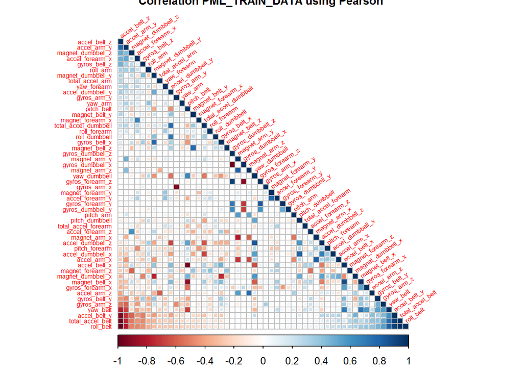

```r
PML_TRAIN_DATA_Num<-sapply(PML_TRAIN_DATA, is.numeric)
cc <- cor(PML_TRAIN_DATA[,PML_TRAIN_DATA_Num], use="pairwise",
          method="pearson")
ord <- order(cc[1,]);cor <- cc[ord, ord]
corrplot(cor,method =  "square",type="lower",tl.cex = 0.5,tl.col = "red",
          tl.offset = 0.4, tl.srt = 35,rect.lwd=2)
title(main="Correlation PML_TRAIN_DATA using Pearson",cex.main=0.9)
```

we observe that variables yaw belt and roll_belt are one of the most correlated with other predictors, we perform a density distribution on this two variables to analyse the difference by classe

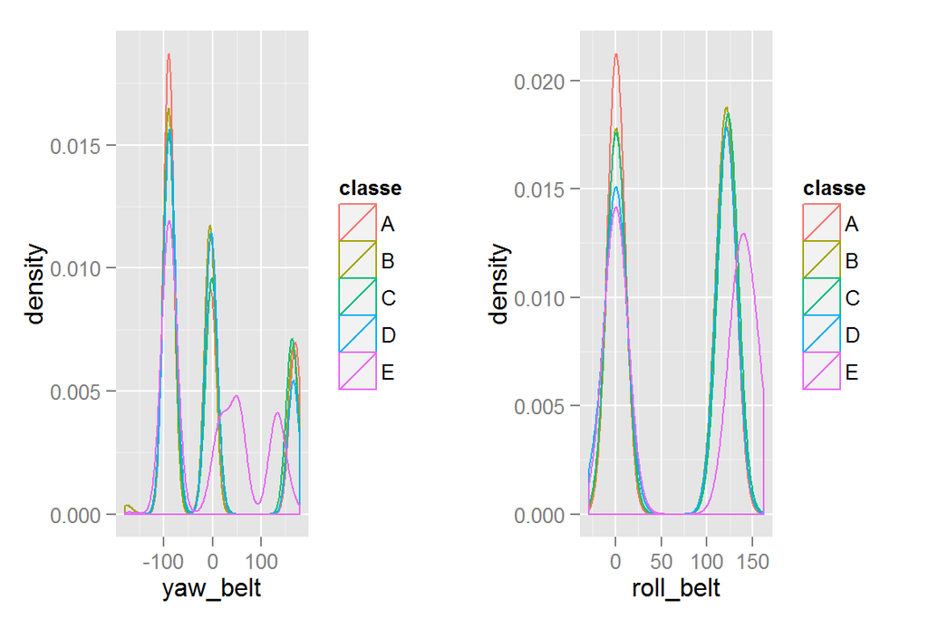

```r
g1<-qplot(yaw_belt,colour=classe,data=PML_TRAIN_DATA,geom="density")
g2<-qplot(roll_belt,colour=classe,data=PML_TRAIN_DATA,geom="density")
grid.arrange(g1,g2,ncol=2)
```

*Prediction Models Exercise:*

*Training and test partition sets:* in this phase we build the prediction models, initially we create two data partition (training and test) with ratio 60% training and 40% test out of training files

```r
set.seed(12345)
INTRAIN <- createDataPartition(PML_TRAIN_DATA$classe, p = .6, list = FALSE)
PMLTRAIN <- PML_TRAIN_DATA[INTRAIN,];PMLTEST <- PML_TRAIN_DATA[-INTRAIN,]
```

*Models development using Caret Package:*

the Caret Package allow us to develop predicitons models using several technics; we will test in the following setps :

- Stochastic Gradient Boosting Model (GBM)
- Support Vector Machine (SVM)
- Regularized Discriminant Analysis (RDA)

*1.Cross Validation Seetings:* we setup the cross validation parameters using the trainControl option

```r
fitControl <- trainControl(method = "repeatedcv", number = 5,repeats = 5,
                           classProbs = TRUE)
set.seed(54321)
```

*2.Caret Models development:* than we execute the training function for each model

```r
HAR_GBM <- train(classe ~ .,data=PMLTRAIN,method = "gbm",
                trControl = fitControl, verbose = FALSE)
HAR_SVM <- train(classe ~ .,data=PMLTRAIN, method = "svmRadial",
                trControl = fitControl)
HAR_RDA <- train(classe ~ .,data=PMLTRAIN,method = "rda",
                 trControl = fitControl)
```

*3.Random Forsts Model development:* we develop the RF models using randomForest library since the application of RF on Caret library require a long execution time

```r
HAR_RF<-randomForest(classe~.,data=PMLTRAIN,ntree=100, importance=TRUE,proximity=TRUE)
```

the variables importance graph on Random forest allow us to analyse the predictors impact on the model

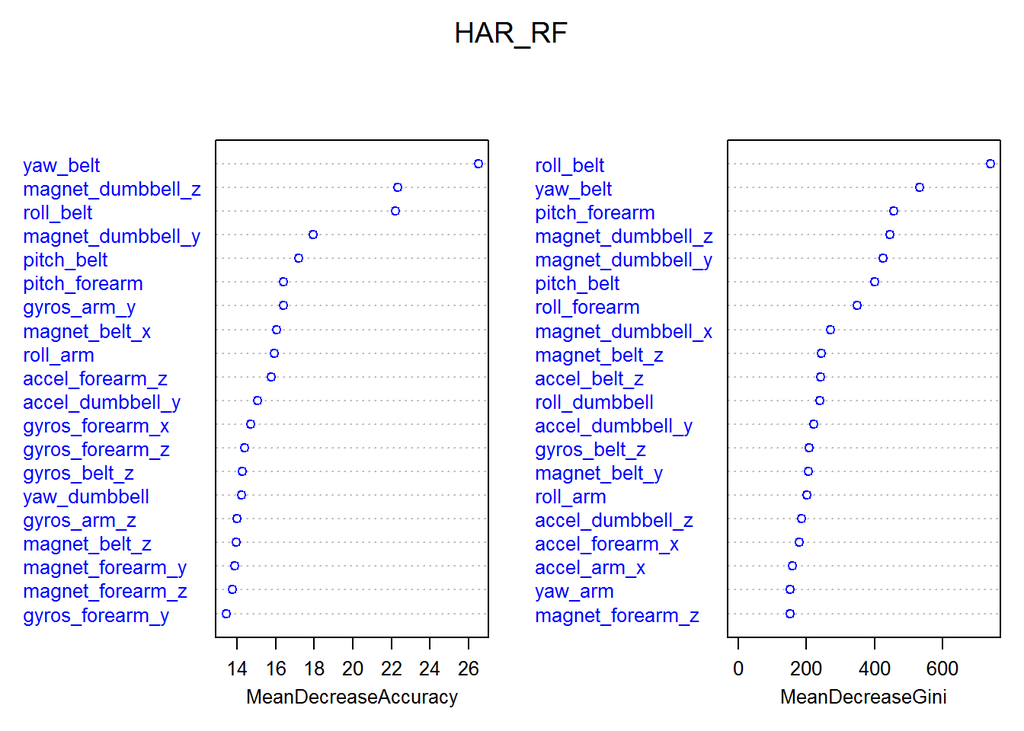

```r
varImpPlot(HAR_RF,n.var=20,cex=0.8,col = "blue")
```

*4.Models performance comparaison:* in order to compare models performance , we run each model on the test parition and we analyse the different confusion matrix and performance indicators like accuracy, specificty, sensibility..etc

```r
n <- ncol(PMLTEST)
HAR_GBMTESTPRED <- predict (HAR_GBM, PMLTEST[,-n])
HAR_SVMTESTPRED <- predict (HAR_SVM, PMLTEST[,-n])
HAR_RDATESTPRED <- predict (HAR_RDA, PMLTEST[,-n])
HAR_RFTESTPRED <- predict (HAR_RF, PMLTEST[,-n])
```

confusion matrix are detailled as following:

```r
confusionMatrix(data = HAR_GBMTESTPRED, PMLTEST[,n])
```

```
## Confusion Matrix and Statistics
##
##           Reference
## Prediction    A    B    C    D    E
##          A 2145   55    1    1    3
##          B   20 1390   45    6   27
##          C   16   40 1277   34   10
##          D    4    1   15 1207   30
##          E    3    1    2   10 1341
##
## Overall Statistics
##
##                Accuracy : 0.9578
##                  95% CI : (0.9531, 0.9622)
##     No Information Rate : 0.2847
##     P-Value [Acc > NIR] : < 2.2e-16
##
##                   Kappa : 0.9466
##  Mcnemar's Test P-Value : 1.963e-13
##
## Statistics by Class:
##
##                      Class: A Class: B Class: C Class: D Class: E
## Sensitivity            0.9803   0.9348   0.9530   0.9595   0.9504
## Specificity            0.9891   0.9842   0.9842   0.9922   0.9974
## Pos Pred Value         0.9728   0.9341   0.9274   0.9602   0.9882
## Neg Pred Value         0.9922   0.9843   0.9900   0.9921   0.9889
## Prevalence             0.2847   0.1935   0.1744   0.1637   0.1836
## Detection Rate         0.2792   0.1809   0.1662   0.1571   0.1745
## Detection Prevalence   0.2870   0.1936   0.1792   0.1636   0.1766
## Balanced Accuracy      0.9847   0.9595   0.9686   0.9758   0.9739
```

```r
confusionMatrix(data = HAR_SVMTESTPRED, PMLTEST[,n])
```

```
## Confusion Matrix and Statistics
##
##           Reference
## Prediction    A    B    C    D    E
##          A 2158  107   43   96   10
##          B   15 1317  103  113   84
##          C   10   62 1003  198  128
##          D    0    0  189  558   61
##          E    5    1    2  293 1128
##
## Overall Statistics
##
##                Accuracy : 0.8022
##                  95% CI : (0.7931, 0.811)
##     No Information Rate : 0.2847
##     P-Value [Acc > NIR] : < 2.2e-16
##
##                   Kappa : 0.7484
##  Mcnemar's Test P-Value : < 2.2e-16
##
## Statistics by Class:
##
##                      Class: A Class: B Class: C Class: D Class: E
## Sensitivity            0.9863   0.8857   0.7485  0.44356   0.7994
## Specificity            0.9534   0.9492   0.9373  0.96110   0.9520
## Pos Pred Value         0.8940   0.8070   0.7159  0.69059   0.7894
## Neg Pred Value         0.9943   0.9719   0.9464  0.89820   0.9548
## Prevalence             0.2847   0.1935   0.1744  0.16372   0.1836
## Detection Rate         0.2808   0.1714   0.1305  0.07262   0.1468
## Detection Prevalence   0.3142   0.2124   0.1823  0.10515   0.1860
## Balanced Accuracy      0.9699   0.9174   0.8429  0.70233   0.8757
```

```r
confusionMatrix(data = HAR_RDATESTPRED, PMLTEST[,n])
```

```
## Confusion Matrix and Statistics
##
##           Reference
## Prediction    A    B    C    D    E
##          A 2022   84    1    3    0
##          B   79 1237   83    2   63
##          C   42  150 1253  153   59
##          D   37    6    1 1078   37
##          E    8   10    2   22 1252
##
## Overall Statistics
##
##                Accuracy : 0.8904
##                  95% CI : (0.8832, 0.8973)
##     No Information Rate : 0.2847
##     P-Value [Acc > NIR] : < 2.2e-16
##
##                   Kappa : 0.8616
##  Mcnemar's Test P-Value : < 2.2e-16
##
## Statistics by Class:
##
##                      Class: A Class: B Class: C Class: D Class: E
## Sensitivity            0.9241   0.8319   0.9351   0.8569   0.8873
## Specificity            0.9840   0.9634   0.9363   0.9874   0.9933
## Pos Pred Value         0.9583   0.8449   0.7562   0.9301   0.9675
## Neg Pred Value         0.9702   0.9598   0.9856   0.9724   0.9751
## Prevalence             0.2847   0.1935   0.1744   0.1637   0.1836
## Detection Rate         0.2631   0.1610   0.1631   0.1403   0.1629
## Detection Prevalence   0.2746   0.1905   0.2156   0.1508   0.1684
## Balanced Accuracy      0.9541   0.8976   0.9357   0.9222   0.9403
```

```r
confusionMatrix(data = HAR_RFTESTPRED, PMLTEST[,n])
```

```
## Confusion Matrix and Statistics
##
##           Reference
## Prediction    A    B    C    D    E
##          A 2184   12    0    0    0
##          B    1 1470    4    0    0
##          C    2    5 1332    8    1
##          D    0    0    4 1250    7
##          E    1    0    0    0 1403
##
## Overall Statistics
##
##                Accuracy : 0.9941
##                  95% CI : (0.9922, 0.9957)
##     No Information Rate : 0.2847
##     P-Value [Acc > NIR] : < 2.2e-16
##
##                   Kappa : 0.9926
##  Mcnemar's Test P-Value : NA
##
## Statistics by Class:
##
##                      Class: A Class: B Class: C Class: D Class: E
## Sensitivity            0.9982   0.9886   0.9940   0.9936   0.9943
## Specificity            0.9978   0.9992   0.9975   0.9983   0.9998
## Pos Pred Value         0.9945   0.9966   0.9881   0.9913   0.9993
## Neg Pred Value         0.9993   0.9973   0.9987   0.9988   0.9987
## Prevalence             0.2847   0.1935   0.1744   0.1637   0.1836
## Detection Rate         0.2842   0.1913   0.1733   0.1627   0.1826
## Detection Prevalence   0.2858   0.1920   0.1754   0.1641   0.1827
## Balanced Accuracy      0.9980   0.9939   0.9958   0.9960   0.9971
```

based on the comparaison of previous confusion matrix we observe that the Random forest model overperform in this case, we consider this model as the final one for deployment.

*Random Forests Model deployment:*

we run the model deployment using the command

```r
answers <- predict(HAR_RF, PML_SUBMISSION)
```